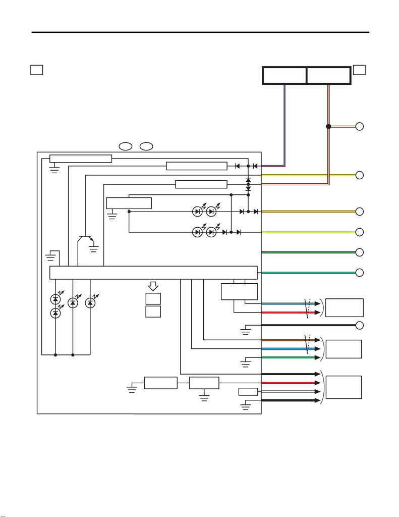

WI-300

Multi-function Display (MFD) System

WIRING SYSTEM

31.Multi-function Display (MFD) System

A: WIRING DIAGRAM

WI-44498

A

B

a a

C

D

MFD

G

F

BR/W

L/R

TFT

LCD

BR/WA3

L/RA1

BR/W

YA9 Y

Y/RA10 Y/R

Y/LA11 Y/L

E

G/RA4 G/R

B:

i240

A:

i122

G/L

B

G/LA12

LA5

BA2

RA6

SB3

WB4

RB5

BB6

GB7

LB1

BRB2

6V REG

MICRO COMPUTER

PASSENGER'S

AIRBAG OFF

SEAT BELT

(PASSENGER'S SEAT)

CONSTANT VOLTAGE CIRCUIT

FB-12

F/B FUSE NO. 2

(IG)

FB-10

M/B FUSE NO. 8

(B)

PASSENGER'S

AIRBAG ON

IMAGE MICRO

COMPUTER

ISO

AMPLIFIER

CAN

TRANSCEIVER &

RECEIVER

REF. TO AUDIO

SYSTEM

[1b] [2d] [3b] [4d]

REF. TO

REARVIEW

CAMERA

SYSTEM [a]

REF. TO CAN

COMMUNICATION

SYSTEM [b]

CONSTANT VOLTAGE CIRCUIT

IG DETECTING CIRCUIT

CONSTANT VOLTAGE

CIRCUIT

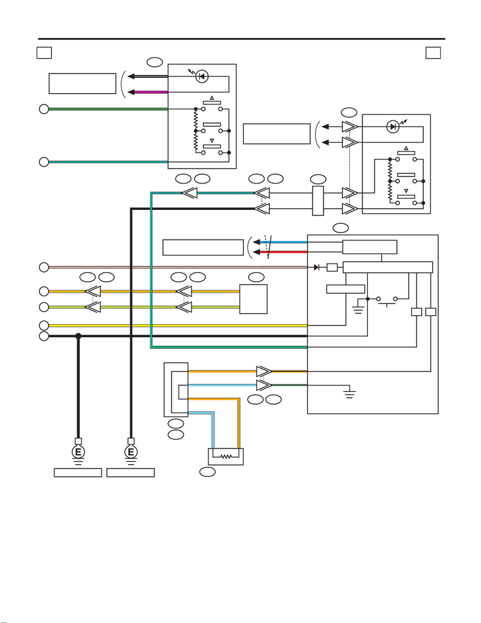

WI-301

Multi-function Display (MFD) System

WIRING SYSTEM

WI-44499

b b

i10

I/F

I/FI/F

B

G

F78

A

ST5

ST3

i231

B553

B68

ST1

i/SET

i238B584

F108

A:

B361

D:

1

C

D

2

413

2

4

1

3

2

BR/W 20

L32

R33

LG/B 36

B/W 4

V1

G/RG/R

3

G/LG/L 2

O/B 27

B38

G/L 29

Y

BR/W

B

Y 28

SB

O

A13

A14

O

SB

D11

D10

SB

O

G/L

B

G/LG/L 5

7

i7

ENTER

i230

B552

7

17

B31

AB1

5

6

Y/L

Y/R

Y/L

Y/R A23

A17

Y/R

Y/L

Y/R

Y/L

B

O

SB

2

1

B

AB6A:

E

F

AIRBAG CM

ROLL CONNECTOR

REF. TO CLEARANCE

LIGHT & ILLUMINATION

LIGHT SYSTEM [1a] [2a]

STEERING SWITCH

REF. TO CLEARANCE

LIGHT & ILLUMINATION

LIGHT SYSTEM [1d] [2d]

MFD SWITCH

THROUGH JOINT

CONNECTOR

TRIP

SWITCH

DRIVE CIRCUIT

REF. TO CAN COMMUNICATION

SYSTEM [b]

REF. TO GND [b]REF. TO GND [e]

AMBIENT SENSOR

MICRO COMPUTER

CAN TRANSCEIVER &

RECEIVER

COMBINATION METER

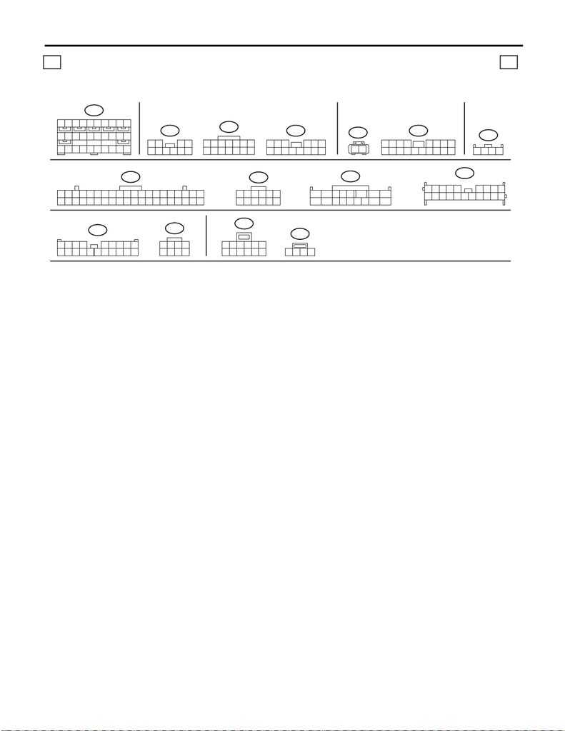

WI-302

Multi-function Display (MFD) System

WIRING SYSTEM

F108

(GR)

1

9

23 8

10

4

11 12 13 14 15 16

567

17 18

A:

ST3

2

1

89

5

12

6

7

34

1110

ST5

3

42121

WI-44500

c c

1234567

8

9

10

11 12 13 14

15 16 17 18 19 20

21 22 23 24 25 26 27 28 29 30

AB6

(Y)

A:

B68

3

42

156

7

13 1411

12

9

10

8

D:

(GR)

B361

123 456

789

10 11 12 13 14

F78

(B)

21

i10

11 12

9

10

7856341

2

15 1613 14 19

18

20

21 22 23 24 26

25

27 28 29 30 31 32 33 34 35 36 37 38 39 40

17

11 12

9

10

78

65341

2

i122

(B)

A:

i230

(GR)

10

13

345 6

14 15 16 17

1211

12 78

9

i240

(B)

1234

5678

B:

i7

(GR)

2143

i231

12345 6789

10 11 12 13 14 15 16 17 18 19 20

(GR)

B31

8765

21

10

9

43

89

19 20

1234 567

10 11 12 13 14 15 16 17 18

i238

LIST OF CONNECTORS